# esATAC Report

Zheng Wei and Wei Zhang

2019-01-13

```r
load("Report2.Rdata")
```

# 1 Summary Table

Sequence files below are set as inputs of the pipeline.

Case files:

| Mate1.files | Mate2.files |
| --- | --- |
| /home/yifei_wan/R/x86_64-pc-linux-gnu-library/3.5/esATAC/extdata/chr20_1.1.fq.gz | /home/yifei_wan/R/x86_64-pc-linux-gnu-library/3.5/esATAC/extdata/chr20_2.1.fq.gz |

Control files:

| Mate1.files | Mate2.files |
| --- | --- |
| /home/yifei_wan/R/x86_64-pc-linux-gnu-library/3.5/esATAC/extdata/chr20_1.2.fq.bz2 | /home/yifei_wan/R/x86_64-pc-linux-gnu-library/3.5/esATAC/extdata/chr20_2.2.fq.bz2 |

Summerized infomation on sequence files has been shown showed below. You can see details in later sections

| Item | Case | Control | Reference |
| --- | --- | --- | --- |
| Sequence Files Type | paired end (PE) | paired end (PE) | SE / PE |
| Original total reads | 0.0M | 0.0M |  |
| – Reads after adapter removing (ratio) | 0.0M (100.00%) | 0.0M (100.00%) | >99% |
| – – Total mapped reads (ratio of original reads) | 0.0M (100.00%) | 0.0M (100.00%) | >95% |
| – – – Unique locations mapped uniquely by reads | 0.0M | 0.0M |  |
| – – – Uniquely mappable reads | 0.0M | 0.0M |  |
| – – – Non-Redundant Fraction (NRF) | 1.00 | 1.00 | >0.7 |
| – – – Locations with only 1 reads mapping uniquely | 0.0M | 0.0M |  |
| – – – Locations with only 2 reads mapping uniquely | 0.0M | 0.0M |  |
| – – – PCR Bottlenecking Coefficients 1 (PBC1) | 1.00 | 1.00 | >0.7 |
| – – – PCR Bottlenecking Coefficients 2 (PBC2) | Inf | Inf | >3 |
| – – – Non-mitochondrial reads (ratio) | 0.0M (100.00%) | 0.0M (100.00%) | >70% |
| – – – – Unique mapped reads (ratio) | 0.0M (93.12%) | 0.0M (92.89%) |  |
| – – – – – Duplicate removed reads (final for use) | 0.0M (93.12%) | 0.0M (92.89%) | >25M |
| – – – – – – Nucleosome free reads (<100bp) | 0.0M (32.22%) | 0.0M (32.35%) |  |
| – – – – – – – Total peaks | 1042 | 1125 |  |
| – – – – – – – Peaks overlaped with union DHS ratio | 55.9% | 55.8% |  |
| – – – – – – – Peaks overlaped with blacklist ratio | 0.0% | 0.0% |  |
| – – – – – – Fraction of reads in peaks (FRiP) | 50.6% | 52.2% |  |

A nucleosome free region (NFR) must be present. A mononucleosome peak must be present in the fragment length distribution. These are reads that span a single nucleosome, so they are longer than 147 bp but shorter than 147*2 bp. Good ATAC-seq datasets have reads that span nucleosomes (which allows for calling nucleosome positions in addition to open regions of chromatin).

- Case

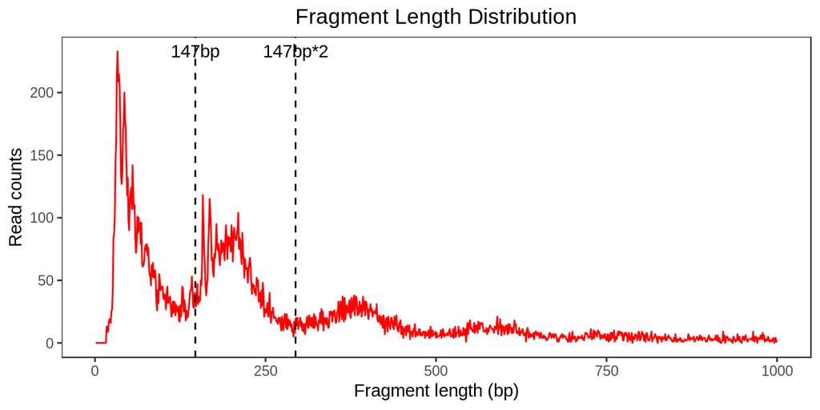

- Control

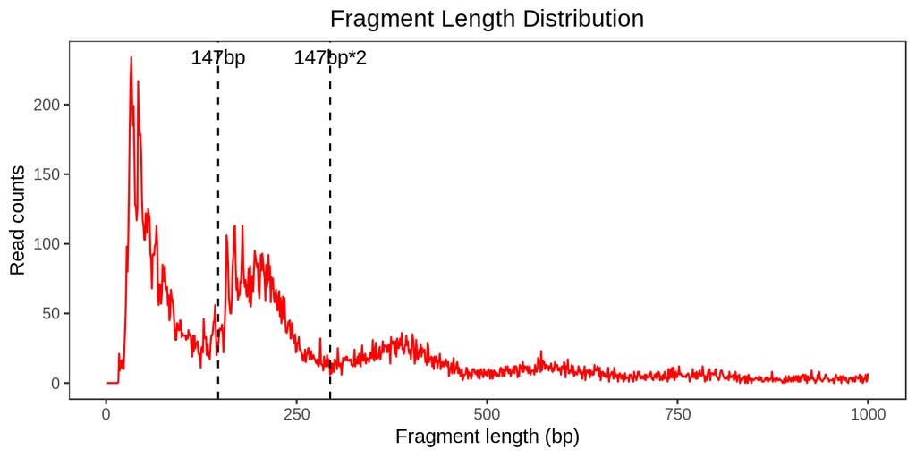

# 2 Sequence Statistics

## 2.1 FastQC

Quality control for the sequence data

Click to Visit Report for case

Click to Visit Report for control

## 2.2 Remove adapter

The adapter sequence are shown below. For paired end reads, if adapters were not setted, the adapters below are identified by AdapterRemoval.

- Adapter for case

| Item | Value |
| --- | --- |
| adapter1 | CTGTCTCTTATACACATCTCCGAGCCCACANNNCATANG |
| adapter2 | CTGTCTCTTATACACATCTGACGCTNTTGTCCTTCAAAG |

- Adapter for control

| Item | Value |
| --- | --- |
| adapter1 | CTGTCTCTTATACACATCTCCGAGCCAATGGCGTGA |
| adapter2 | CTGTCTCTTATACACATCTGACGCTGTTTCTTTTTT |

The statistic of adapter removing are show below.

| Items | Case | Control |
| --- | --- | --- |
| Total number of read pairs | 25000 | 25000 |
| Number of unaligned read pairs | 13581 | 13493 |
| Number of well aligned read pairs | 11419 | 11507 |
| Number of discarded mate 1 reads | 0 | 0 |
| Number of singleton mate 1 reads | 0 | 0 |
| Number of discarded mate 2 reads | 0 | 0 |
| Number of singleton mate 2 reads | 0 | 0 |
| Number of reads with adapters[1] | 5906 | 5846 |
| Number of retained reads | 50000 | 50000 |
| Number of retained nucleotides | 2451360 | 2449920 |
| Average length of retained reads | 49.0272 | 48.9984 |

For detail, you can visit [Website of AdapterRemoval on Github](https://github.com/MikkelSchubert/adapterremoval).

# 3 Reads Alignment Statistics

## 3.1 Bowtie2 alignment log

- For case

```
## [1] "25000 reads; of these:"
## [2] "  25000 (100.00%) were paired; of these:"
## [3] "    1 (0.00%) aligned concordantly 0 times"
## [4] "    23284 (93.14%) aligned concordantly exactly 1 time"
## [5] "    1715 (6.86%) aligned concordantly >1 times"
## [6] "100.00% overall alignment rate"
```

- For control

```
## [1] "25000 reads; of these:"
## [2] "  25000 (100.00%) were paired; of these:"
## [3] "    0 (0.00%) aligned concordantly 0 times"
## [4] "    23228 (92.91%) aligned concordantly exactly 1 time"
## [5] "    1772 (7.09%) aligned concordantly >1 times"
## [6] "100.00% overall alignment rate"
```

## 3.2 Library complexity

[output not shown]

## 3.3 Filtering statistics

| Item | Case | Control | Reference |
| --- | --- | --- | --- |
| Original total reads | 0.0M (25000) | 0.0M (25000) |  |
| Reads after adapter removing (ratio) | 0.0M (100.00%, 25000 / 25000) | 0.0M (100.00%, 25000 / 25000) | >99% |
| Total mapped reads (ratio of original reads) | 0.0M (100.00%, 24999 / 25000) | 0.0M (100.00%, 25000 / 25000) | >95% |
| – Non-mitochondrial reads (ratio) | 0.0M (100.00%, 24999 / 24999) | 0.0M (100.00%, 25000 / 25000) | >70% |
| – – Unique mapped reads (ratio) | 0.0M (93.12%, 23279 / 24999) | 0.0M (92.89%, 23222 / 25000) | >60% |
| – – – Duplicate removed reads (ratio final for use) | 0.0M (93.12%, 23279 / 24999) | 0.0M (92.89%, 23222 / 25000) | >25M,>60% |

## 3.4 Fragment size distribution

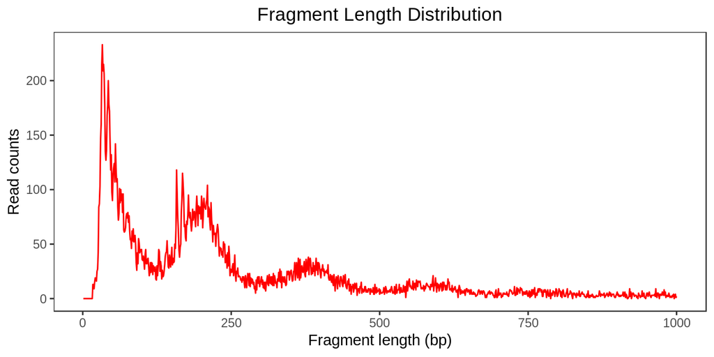

```r
library(ggplot2)
library(stats)
load("Report2.Rdata")

getFsdG1G2 <- function(readsCounts){



    strength<-Mod(fft(readsCounts$counts))/length(readsCounts$counts)
    periodx<-length(readsCounts$counts)/(1:(length(readsCounts$counts)-1))
    strength<-strength[2:length(strength)]

    rs1<-as.data.frame(cbind(periodx[periodx<20&periodx>2],strength[periodx<20&periodx>2],0))
    rs2<-as.data.frame(cbind(periodx[periodx<400&periodx>2],strength[periodx<400&periodx>2],1))
    rs<-rbind(rs1,rs2)
    colnames(rs)<-c("period","strength","check")

    g1<-ggplot(rs[rs["check"]==0,]) + geom_vline(xintercept = 10.4, linetype=2)+ geom_line(aes(x=period,y=strength),color="Red")+ theme_bw() + theme(panel.grid =element_blank()) + annotate("text", x = 10.4, y = max(rs[rs["check"]==0,2]), label = "10.4bp") +xlab("period") + ylab("strength")+ labs(title = "the Pitch of the DNA Helix") + theme(plot.title = element_text(hjust = 0.5))

    g2<-ggplot(rs[rs["check"]==1,]) + geom_vline(xintercept = 186, linetype=2)+ geom_line(aes(x=period,y=strength),color="Red")+ theme_bw() + theme(panel.grid =element_blank()) + annotate("text", x = 186, y = max(rs[rs["check"]==1,2]), label = "186bp") +xlab("period") + ylab("strength")+ labs(title = "Nucleosome") + theme(plot.title = element_text(hjust = 0.5))
    return(list(g1,g2))
}
readsCounts1<-getReportVal(caselist$atacProcs$fragLenDistr,"readsCounts")
readsCounts2<-getReportVal(ctrllist$atacProcs$fragLenDistr,"readsCounts")
ggplot(readsCounts1[1:1000,], aes(length,counts))+geom_path(color="Red")+xlab("Fragment length (bp)")+ylab("Read counts") + theme_bw() + theme(panel.grid =element_blank()) + labs(title = "Fragment Length Distribution") + theme(plot.title = element_text(hjust = 0.5))
```

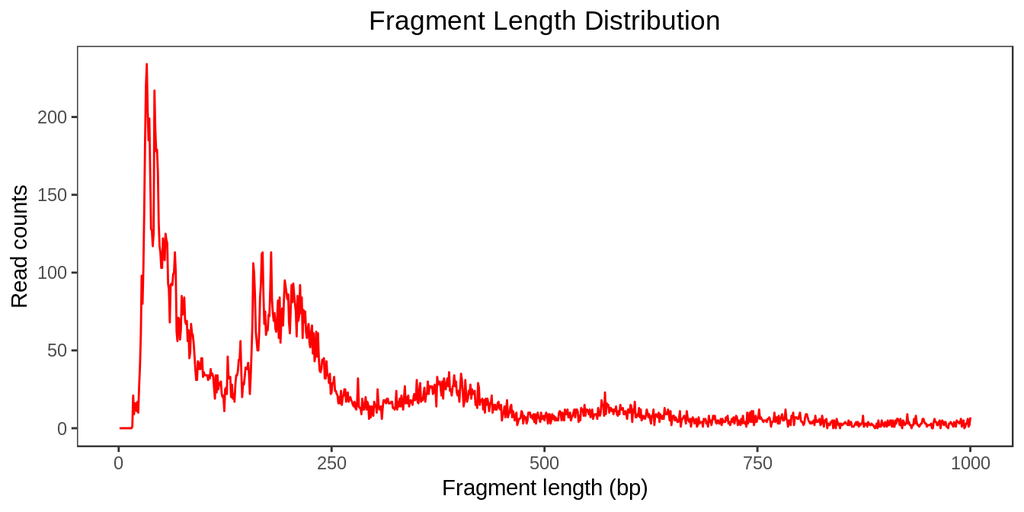

```r
ggplot(readsCounts2[1:1000,], aes(length,counts))+geom_path(color="Red")+xlab("Fragment length (bp)")+ylab("Read counts") + theme_bw() + theme(panel.grid =element_blank()) + labs(title = "Fragment Length Distribution") + theme(plot.title = element_text(hjust = 0.5))
```

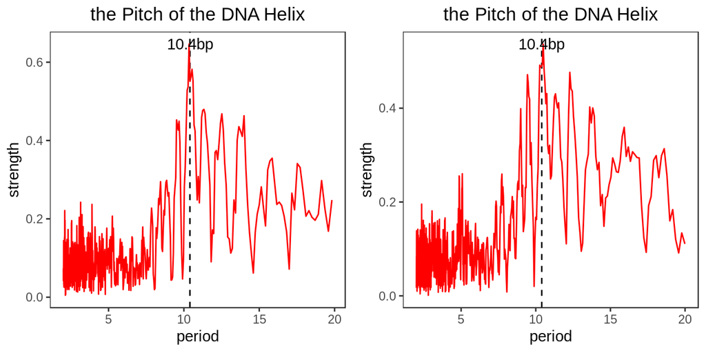

```r
g112<-getFsdG1G2(readsCounts1)
g212<-getFsdG1G2(readsCounts2)

library(gridExtra)
grid.arrange(g112[[1]], g212[[1]],ncol=2)
```

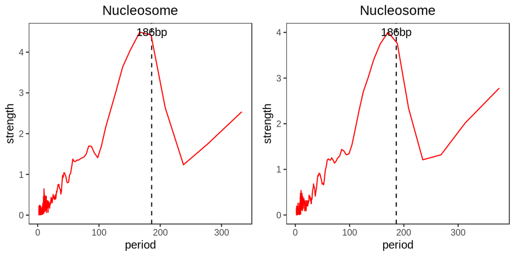

```r
grid.arrange(g112[[2]], g212[[2]],ncol=2)
```

## 3.5 TSS enrichment

The nucleosome free reads (<100bp) and monnucleosome span reads (180~247bp) enrichment around transcription starting site (TSS) are shown below.

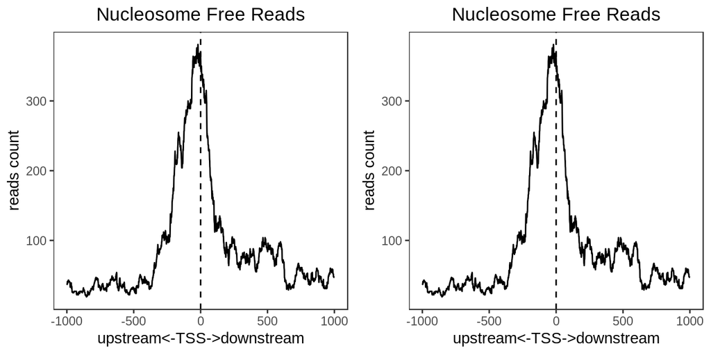

```r
library(ggplot2)
library(gridExtra)
load("Report2.Rdata")
df<-getReportVal(caselist$atacProcs$tssqc100,"tss")
g11<-ggplot(df,aes(pos,counts))+geom_line()+ geom_vline(xintercept = 0, linetype=2)+xlab("upstream<-TSS->downstream")+ylab("reads count")+theme_bw() + theme(panel.grid =element_blank()) + labs(title = "Nucleosome Free Reads") + theme(plot.title = element_text(hjust = 0.5))
df<-getReportVal(caselist$atacProcs$tssqc180_247,"tss")
g12<-ggplot(df,aes(pos,counts))+geom_line()+ geom_vline(xintercept = 0, linetype=2)+xlab("upstream<-TSS->downstream")+ylab("reads count")+theme_bw() + theme(panel.grid =element_blank()) + labs(title = "Monnucleosome Span Reads") + theme(plot.title = element_text(hjust = 0.5))

df<-getReportVal(caselist$atacProcs$tssqc100,"tss")
g21<-ggplot(df,aes(pos,counts))+geom_line()+ geom_vline(xintercept = 0, linetype=2)+xlab("upstream<-TSS->downstream")+ylab("reads count")+theme_bw() + theme(panel.grid =element_blank()) + labs(title = "Nucleosome Free Reads") + theme(plot.title = element_text(hjust = 0.5))
df<-getReportVal(caselist$atacProcs$tssqc180_247,"tss")
g22<-ggplot(df,aes(pos,counts))+geom_line()+ geom_vline(xintercept = 0, linetype=2)+xlab("upstream<-TSS->downstream")+ylab("reads count")+theme_bw() + theme(panel.grid =element_blank()) + labs(title = "Monnucleosome Span Reads") + theme(plot.title = element_text(hjust = 0.5))
grid.arrange(g11, g21, ncol=2)
```

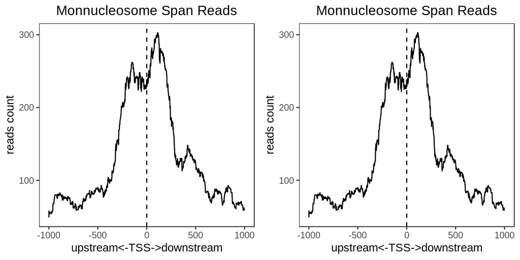

```r
grid.arrange(g12, g22, ncol=2)
```

# 4 Peak Statistics

## 4.1 Blacklist ratio

| Items | Case | Control |
| --- | --- | --- |
| Total peaks | 1042 | 1125 |
| Blacklist regions | 0 | 0 |
| Ratio | 0.00 | 0.00 |

## 4.2 DHS ratio

| Items | Case | Control |
| --- | --- | --- |
| Total peaks | 1042 | 1125 |
| DHS regions | 582 | 628 |
| Ratio | 0.56 | 0.56 |

## 4.3 Fraction of reads in peaks (FRiP)

| Items | Case | Control |
| --- | --- | --- |
| The number of reads in peak | 3799 | 3918 |
| The number of total reads | 7501 | 7512 |
| The number of total peaks | 1042 | 1125 |
| FRiP | 0.51 | 0.52 |

## 4.4 Peak annotation

- For case

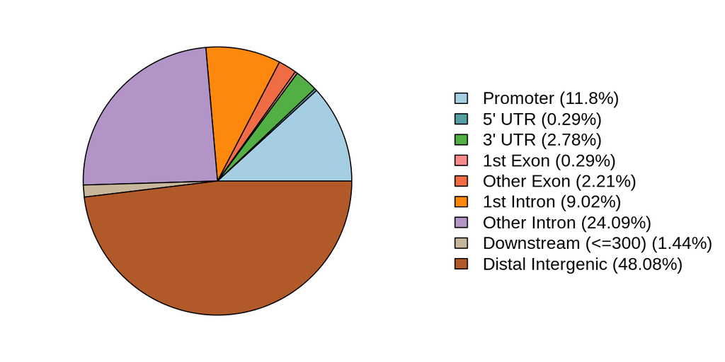

- For control

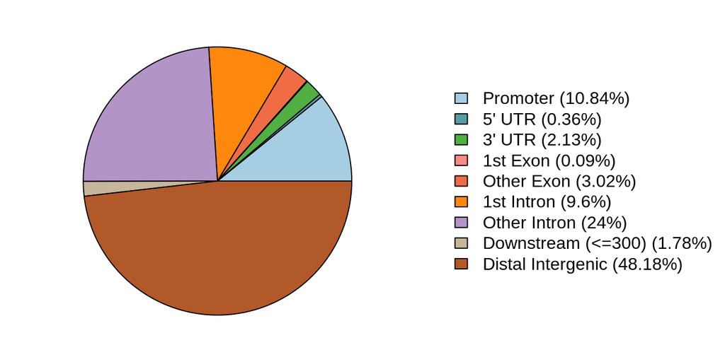

# 5 Case Control Peak Compare

The following is the peak comparation result for case and control.

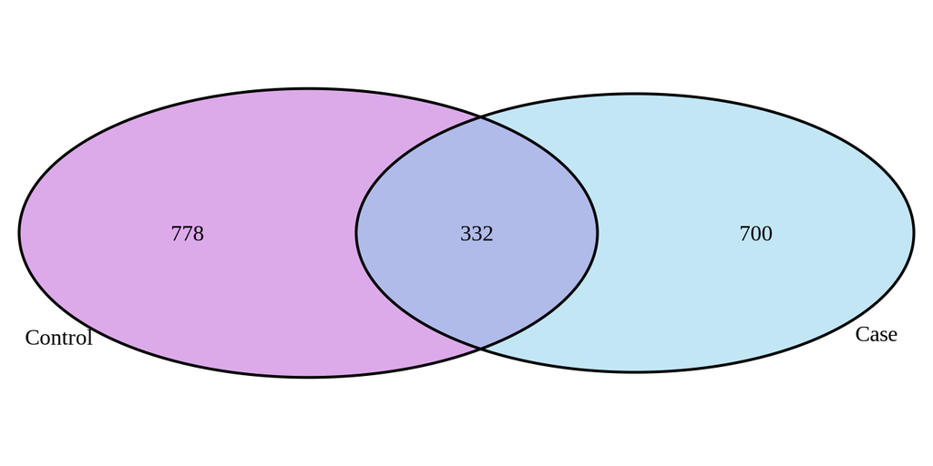

The total peaks in case are 1042, specific peaks in case are 700.

The total peaks in control are 1125, specific peaks in control are 778.

The overlap peaks are merged to 332 peaks.

# 6 GO Analysis

Gene ontology analysis for all genes around specific peak regions of case and control.

## 6.1 Significant GO terms of genes associated with case specific peaks

Click to Visit Case Differential Go Analysis file

## 6.2 Significant GO terms of genes associated with control specific peaks

Click to Visit Ctrl Differential Go Analysis file

# 7 Motif Enrichment Analysis

This function takes case and control specific peaks as foreground respectively, overlap peaks between case and control as background.

## 7.1 Significant motifs of case specific peaks

| motif | motif length | p_value |
| --- | --- | --- |
| Ddit3Cebpa | 12 | 0 |
| Foxd3 | 12 | 0 |
| PPARG | 20 | 0 |
| SRY | 9 | 0 |
| HLTF | 10 | 0 |
| Spz1 | 11 | 0 |
| NR1H2RXRA | 17 | 0 |
| NFICTLX1 | 14 | 0 |
| EWSR1FLI1 | 18 | 0 |
| REST | 21 | 0 |
| PLAG1 | 14 | 0 |
| Bcl6 | 14 | 0 |
| CDX2 | 11 | 0 |
| Klf1 | 11 | 0 |
| Nr1h3Rxra | 19 | 0 |

## 7.2 Significant motifs of control specific peaks

| motif | motif length | p_value |
| --- | --- | --- |
| Foxd3 | 12 | 0 |
| MZF1var2 | 10 | 0 |
| PBX1 | 12 | 0 |
| SRY | 9 | 0 |
| REL | 10 | 0 |
| Spz1 | 11 | 0 |
| Znf423 | 15 | 0 |
| NFICTLX1 | 14 | 0 |
| EWSR1FLI1 | 18 | 0 |
| REST | 21 | 0 |
| PLAG1 | 14 | 0 |
| Bcl6 | 14 | 0 |
| Crx | 11 | 0 |
| Gfi1b | 11 | 0 |
| HNF4G | 15 | 0 |

# 8 Genomic Footprint

The following is the footprint for motif occurance of case&control peaks.

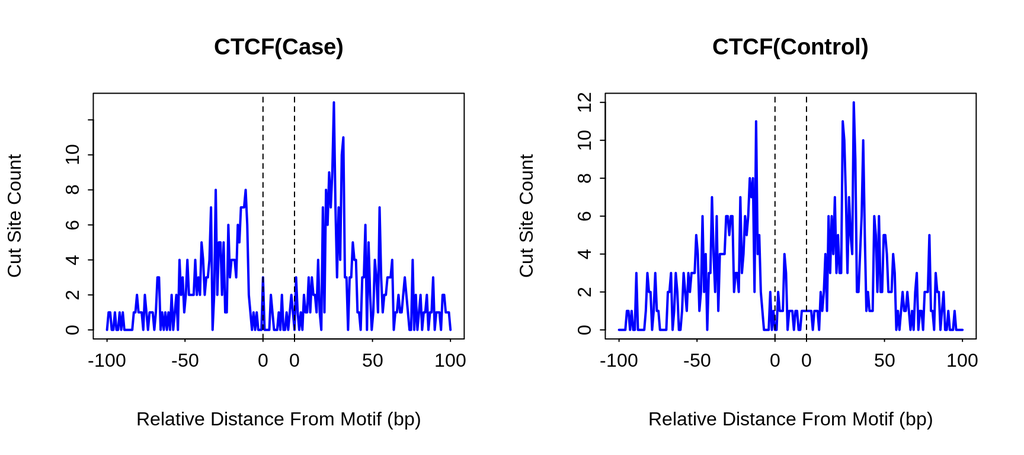

For all footprint of case sample, The absolute path is /home/yifei_wan/Projects/AH_BioPharma/ATACseq/20190113_test/Footprint_Case_data/FP_PDF_Case_data.

For all footprint of control sample, The absolute path is /home/yifei_wan/Projects/AH_BioPharma/ATACseq/20190113_test/Footprint_Control_data/FP_PDF_Control_data.

The following is the footprint for motif occurance of case&control specific peaks.

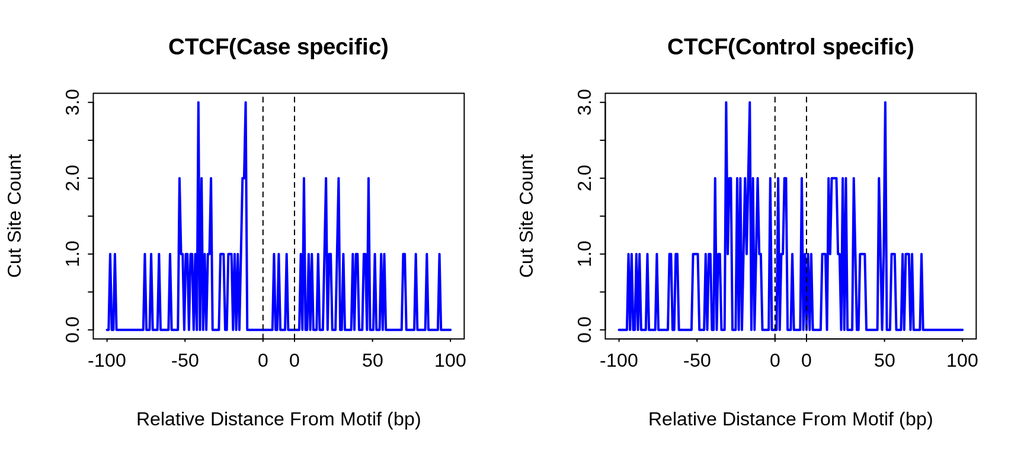

For all footprint of case specific, The absolute path is /home/yifei_wan/Projects/AH_BioPharma/ATACseq/20190113_test/Footprint_Case_specific/FP_PDF_Case_specific.

For all footprint of control specific, The absolute path is /home/yifei_wan/Projects/AH_BioPharma/ATACseq/20190113_test/Footprint_Control_specific/FP_PDF_Control_specific.

# 9 Annotation of Items in Table

For single end sequencing data, esATAC will counts reads number.

For paired end sequencing data, esATAC will counts read pairs or fragment number.

- **Sequence files type** is the type of sequencing data: single end data and paired end data. If paired end reads are stored in one file interleavedly rather than two files, “it is call”interleaved.
- **Original total reads** is the sample’s raw total reads (pairs) number.
- **Reads after adapter removing (ratio)** is the reads (pairs) number after adapter removing and the percentage of retained reads in original total reads. The larger value shows the better quality.
- **Total mapped reads (ratio)**  
  is the reads (pairs) number mapped to reference genome and the percentage of mapped reads in original total reads (alignment rate). ENCODE recommend that the alignment rate, or percentage of mapped reads, should be greater than 95%, though values >80% may be acceptable.
- **Unique locations mapped uniquely**  
  is the number of distinct uniquely mapping reads (i.e. after removing duplicates).
- **Non-Redundant Fraction (NRF)** is the value of: Unique locations mapped uniquely (the number of positions in the genome that uniquely mappable reads map to) / the total number of uniquely mappable reads.

[output not shown]

[output not shown]

- **PCR Bottlenecking Coefficients 2 (PBC2)** is the value of: Locations with only 1 reads mapping uniquely / Locations with only 2 reads mapping uniquely. ENCODE recommend that PBC2>3 for ATAC-seq data.

| $PBC2$ value range | Bottlenecking level |
| --- | --- |
| $PBC2<1$ | Severe |
| $1\le PBC2 \le 3$ | Moderate |
| $PBC2>3$ | None |